# Compte Rendu TD ACP

Samy Mekkaoui

26/02/2021

# Introduction

Dans ce TP, nous allons nous intéresser à une méthode de codage de l’ACP que nous allons tester sur une base de données de 27 individus qui ont effectué des épreuves sportives. Le dataset que nous allons utiliser s’appelera “decathlon2” et on essayera de plot un graphique qui permettra de comprendre les différentes interactions entre les individus par rapport aux épreuves auxquels ils ont participé ainsi que les interactions qui peuvent exister entre les épreuves.

# Réponses aux Questions

### Question n°4

```r
d=10
n=2000
X=matrix(rnorm(d*n),nrow=d,ncol=n)

t0=proc.time()[3]
eigen(X%*%t(X))$values
```

```
##  [1] 2178.235 2122.815 2057.046 2032.328 1979.322 1954.326 1904.436 1866.499
##  [9] 1790.776 1713.251
```

```r
proc.time()[3]-t0
```

```
## elapsed
##    0.01
```

```r
# On calcule le temps pour calculer les valeurs propres de la matrice X%*%t(X)

t1=proc.time()[3]
ev=eigen(t(X)%*%X)$values
proc.time()[3]-t1
```

```
## elapsed
##   15.54
```

```r
#On calcule le temps pour calculer les valeurs propres de la matrice t(X)X%*%X

#On voit que le temps de calcul des valeurs propres de X%*%t(X) est plus rapide puisque c'est une matrice 10x10.Or la matrice t(X)*%*X était de dimension 2000x2000 mais par des arguments d'algèbre linéaire, on sait que les 10 premières valeurs propres sont les mêmes. Ainsi, il suffit de calculer les valeurs propres de la matrice de plus petite dimension ici X*%*t(X) afin de minimiser les calculs.
```

### Question n°5

On peut utiliser ce package car on sait que l’ACP permet de réduire la dimension et que les valeurs propres de module maximal sont celles qui vont permettre de mieux représenter la base de données initiale ( On doit chercher l’inertie maximale pour ne pas que le dataset de base soit totalement différent). Ainsi, la méthode eigs permet d’effectuer une ACP sur un gros volume de données.

### Question sur le codage de l’ACP

#### Partie Code

```r
#Initialisation
library(dplyr)
library(ggplot2)
library("FactoMineR")
library("factoextra")

# Question 1

decathlon2.active <- t(decathlon2[,1:10])

# Question 2

a1=mean(decathlon2.active[1,])
a2=mean(decathlon2.active[2,])
a3=mean(decathlon2.active[3,])
a4=mean(decathlon2.active[4,])
a5=mean(decathlon2.active[5,])
a6=mean(decathlon2.active[6,])
a7=mean(decathlon2.active[7,])
a8=mean(decathlon2.active[8,])
a9=mean(decathlon2.active[9,])
a10=mean(decathlon2.active[10,])

#On calcule les moyennes des individus pour chacune des épreuves

a<-c(a1,a2,a3,a4,a5,a6,a7,a8,a9,a10)

m=matrix(1:1,nrow=10,ncol=27,byrow=TRUE)

b1=a1*m[1,]
b2=a2*m[2,]
b3=a3*m[3,]
b4=a4*m[4,]
b5=a5*m[5,]
b6=a6*m[6,]
b7=a7*m[7,]
b8=a8*m[8,]
b9=a9*m[9,]
b10=a10*m[10,]

l=c(b1,b2,b3,b4,b5,b6,b7,b8,b9,b10)

c=matrix(l,nrow=10,ncol=27,byrow=TRUE)


De<-decathlon2.active-c

#On a centré la matrice

# Question 3

d1=sd(decathlon2.active[1,])
d2=sd(decathlon2.active[2,])
d3=sd(decathlon2.active[3,])
d4=sd(decathlon2.active[4,])
d5=sd(decathlon2.active[5,])
d6=sd(decathlon2.active[6,])
d7=sd(decathlon2.active[7,])
d8=sd(decathlon2.active[8,])
d9=sd(decathlon2.active[9,])
d10=sd(decathlon2.active[10,])

# on calcule les écarts types pour chacune des épreuves

De[1,]<-De[1,]/d1
De[2,]<-De[2,]/d2
De[3,]<-De[3,]/d3
De[4,]<-De[4,]/d4
De[5,]<-De[5,]/d5
De[6,]<-De[6,]/d6
De[7,]<-De[7,]/d7
De[8,]<-De[8,]/d8
De[9,]<-De[9,]/d9
De[10,]<-De[10,]/d10

#On réduit la matrice

print(De)
```

```
##                  SEBRLE        CLAY     BERNARD     YURKOV  ZSIVOCZKY
## X100m         0.1696200 -0.82443206  0.09861628  1.2346758  0.4891367
## Long.jump     0.7309898  0.11952501 -0.45796950 -0.9335532 -0.2201776
## Shot.put      0.3427320 -0.33874677 -0.35070253  0.7731397 -1.2712967
## High.jump     0.7516136 -1.44511282 -0.81747669  1.0654317  0.1239775
## X400m         0.5131487  0.06291188 -0.38732495  1.1373407 -0.7045373
## X110m.hurdle  0.4111900 -0.94999079  1.04924356  1.7298340 -0.6947694
## Discus       -0.3196978  1.70943959 -1.15813616  0.4110246  0.2392612
## Pole.vault    0.7078996  0.32409863  1.85930269 -0.4435034 -1.5949064
## Javeline      0.9313823  0.35025074  0.85109442  0.9791728 -0.5635022
## X1500m        1.2914594  2.25169807  0.15485029 -0.2076888 -1.0307506
##                McMULLEN   MARTINEAU       HERNU      BARRAS       NOOL
## X100m        -0.5759190  2.29973153  1.34118134  1.19917390  1.1991739
## Long.jump    -0.1862074 -1.88472065  0.66304925 -1.34119640 -0.3220884
## Shot.put     -0.9365352  0.03188205 -0.15941024 -0.54199483 -2.2277581
## High.jump     1.3792498 -0.50365862 -1.44511282 -0.50365862 -0.1898406
## X400m         0.6154753  0.85082633  1.83316122  0.17547109 -0.1110433
## X110m.hurdle -0.2481319  0.92163285  1.19812271 -0.03544742  1.6872971
## Discus       -0.1275556  0.80113133  0.04129654 -0.80005309 -2.0169533
## Pole.vault   -1.5949064  0.32409863 -0.05970238 -0.44350339 -0.8273044
## Javeline     -0.3723405 -1.14463385 -0.21558793 -0.55776739 -0.1677975
## X1500m        0.6447680 -1.60885346  0.64476799  0.34101901 -1.1679275
##              BOURGUIGNON     Sebrle       Clay      Karpov       Macey
## X100m          1.3056795 -0.5049153 -1.9604915 -1.74748039 -0.36290789
## Long.jump     -1.9186909  1.6142167  2.0218599  1.51230589  0.35731686
## Shot.put      -1.2952082  2.1719646  0.8209628  1.65786653  1.41875116
## High.jump     -1.4451128  1.2746437  0.6470076  0.96082568  1.58846181
## X400m          1.8945572 -0.9705863 -0.1212759 -2.55664784 -0.34639433
## X110m.hurdle   2.4954982 -0.9499908 -0.7798432 -1.12013839  0.13470019
## Discus        -1.2687634  1.1271907  1.5318537  1.98018532  1.01656342
## Pole.vault     0.7078996  0.6311394  0.2473384 -0.90406461 -1.67166664
## Javeline      -0.6954038  2.3325977  2.1777567 -0.53100475  0.02718744
## X1500m         1.2914594  0.1460318  0.3410190 -0.04013696 -1.28354810
##                  Warners   Zsivoczky       Hernu     Bernard    Schwarzl
## X100m        -1.32145809 -0.29190417 -0.07889302 -1.07294507 -0.04339116
## Long.jump     1.27451403 -0.76370189 -0.59385056  0.39128713  0.42525740
## Shot.put     -0.07571987  0.91660890  0.12752819  0.30686472 -0.63764097
## High.jump    -0.29444658  1.27464375  0.33318955  1.27464375 -0.60826465
## X400m        -1.36965984  0.09360985 -0.59197805 -0.18267184  0.46198543
## X110m.hurdle -1.03506459  0.96416975 -0.52462178 -0.69476938 -0.52462178
```

[output cut: 11 more lines]

```
## Discus       -0.07224199 -0.12755563 -0.005283369  1.19414933 -1.0911775
## Pole.vault    0.63113944  0.63113944 -0.904064610  0.32409863  0.3240986
## Javeline     -0.93053273  0.49171040  1.191362267 -1.53078051 -1.2516844
## X1500m        0.89266635  0.02943135 -1.119915585  2.12431946 -0.0411168
##                    Nool       Drews
## X100m        -0.6824246 -0.43391161
## Long.jump     0.5611385  0.05158448
## Shot.put     -0.3387468 -1.76148319
## High.jump    -1.2359008 -1.23590078
## X400m        -0.5101168 -0.81709646
## X110m.hurdle  0.6451430 -1.03506459
## Discus       -0.8146093 -1.37939073
## Pole.vault    2.1663435  0.63113944
## Javeline      0.5758216 -1.29756322
## X1500m       -0.2145477 -0.42227277
```

```r
#On voit que les valeurs prises par les variables centrées sont du même ordre de grandeur ce qui permet une comparaison plus ohérente

#Question 4

HatSigma<- (De%*%t(De))/26

print(HatSigma)
```

```
##                    X100m   Long.jump    Shot.put  High.jump       X400m
## X100m         1.00000000 -0.73779317 -0.37031804 -0.3146495  0.57034535
## Long.jump    -0.73779317  1.00000000  0.37378475  0.2682078 -0.50366873
## Shot.put     -0.37031804  0.37378475  1.00000000  0.5747998 -0.20735876
## High.jump    -0.31464949  0.26820783  0.57479981  1.0000000 -0.26166031
## X400m         0.57034535 -0.50366873 -0.20735876 -0.2616603  1.00000000
## X110m.hurdle  0.66997900 -0.55211579 -0.27016343 -0.2022579  0.59701398
## Discus       -0.38937605  0.32876524  0.72251794  0.4210187 -0.25453258
## Pole.vault    0.01156433  0.07982045 -0.06837068 -0.5512958  0.11156898
## Javeline     -0.26635476  0.28806781  0.47558572  0.2105179  0.02350554
## X1500m       -0.17805307  0.17332597  0.00959628 -0.1569902  0.18346035
##              X110m.hurdle     Discus  Pole.vault    Javeline      X1500m
## X100m          0.66997900 -0.3893760  0.01156433 -0.26635476 -0.17805307
## Long.jump     -0.55211579  0.3287652  0.07982045  0.28806781  0.17332597
## Shot.put      -0.27016343  0.7225179 -0.06837068  0.47558572  0.00959628
## High.jump     -0.20225787  0.4210187 -0.55129583  0.21051789 -0.15699017
## X400m          0.59701398 -0.2545326  0.11156898  0.02350554  0.18346035
## X110m.hurdle   1.00000000 -0.4213608  0.12118697  0.09655757 -0.10331329
## Discus        -0.42136077  1.0000000 -0.26096827  0.26391816  0.18543496
## Pole.vault     0.12118697 -0.2609683  1.00000000  0.13536783  0.31577847
## Javeline       0.09655757  0.2639182  0.13536783  1.00000000 -0.04474997
## X1500m        -0.10331329  0.1854350  0.31577847 -0.04474997  1.00000000
```

```r
#Question 5

elmtPropre = eigen(HatSigma)
P <- elmtPropre$vectors
D <- elmtPropre$values


#Question 6

Tr=sum(diag(HatSigma)) # Trace de la matrice de covariance
S=sum(D)

print(Tr) # Variance totale du nuage de points
```

```
## [1] 10
```

```r
print(S)
```

```
## [1] 10
```

```r
# On voit que la variance totale du nuage de points est égale à la trace de la matrice de covariance mais aussi à la trace de D car la trace est invariante par similitude

# Questions 7 et 8

a<-eigen(HatSigma)$vectors[,1]/(sqrt(eigen(HatSigma)$values[1]))

b<-eigen(HatSigma)$vectors[,2]/(sqrt(eigen(HatSigma)$values[2]))
c<-eigen(HatSigma)$vectors[,3]/(sqrt(eigen(HatSigma)$values[3]))
P1<-matrix(c(a,b),nrow=10,ncol=2,byrow=FALSE)
P2<-matrix(c(a,c),nrow=10,ncol=2,byrow=FALSE)

Projection12prem=t(De)%*%P1
Projection13prem=t(De)%*%P2
Projection12prem=-Projection12prem
Projection13prem=-Projection13prem
```

#### Suite Question 7

La i-ème coordonnée du vecteur $\frac{v_1}{\sqrt{e_1}}$ où v1 est le vecteur propre associé à la plus grande valeur propre e1 représente la corrélation entre le sport ‘i’ et la composante principale n°1. On projette ce vecteur sur la matrice dont les lignes représentent les athlètes et les colonnes représentent les sports c’est-à-dire la transposée de la matrice initiale. Ainsi, la i-ème coordonnée du produit matriciel correspond à $\sum{j}(^tC_i)_j\times x_j$ avec Ci la i-ème colonne de la matrice decathlon2.active (colonne des performances du i-ème athlète dans chaque sport centré et réduit) et xj la corrélation entre la première composante principale et le sport ‘j’. Cela nous donne donc la performance du i-ème athlète au ‘nouveau sport’ représentant la première composante principale. On procède de la même manière pour le vecteur propre v2 associé à la deuxième plus grande valeur propre e2.Ainsi, celà revient à bien calculer le produit de l’énoncé $^{t}De\times[\frac{v_1}{\sqrt{e_1}}, \frac{v_2}{\sqrt{e_2}}]$ ou De est la matrice centrée réduite de decathlon2.active

#### Partie sur le Plot des Graphiques

##### Graphique obtenue à partir du code précédent

##### Graphique dans le plan factoriel des 2 plus grandes valeurs propres

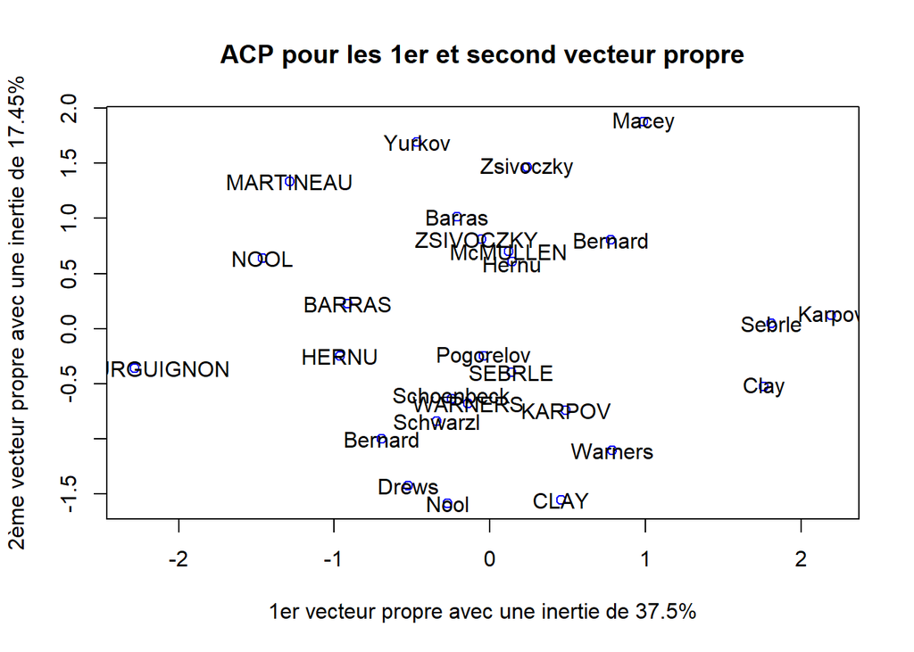

##### Graphique dans le plan factoriel de la 1ère et de la 3ème plus grande valeur propre

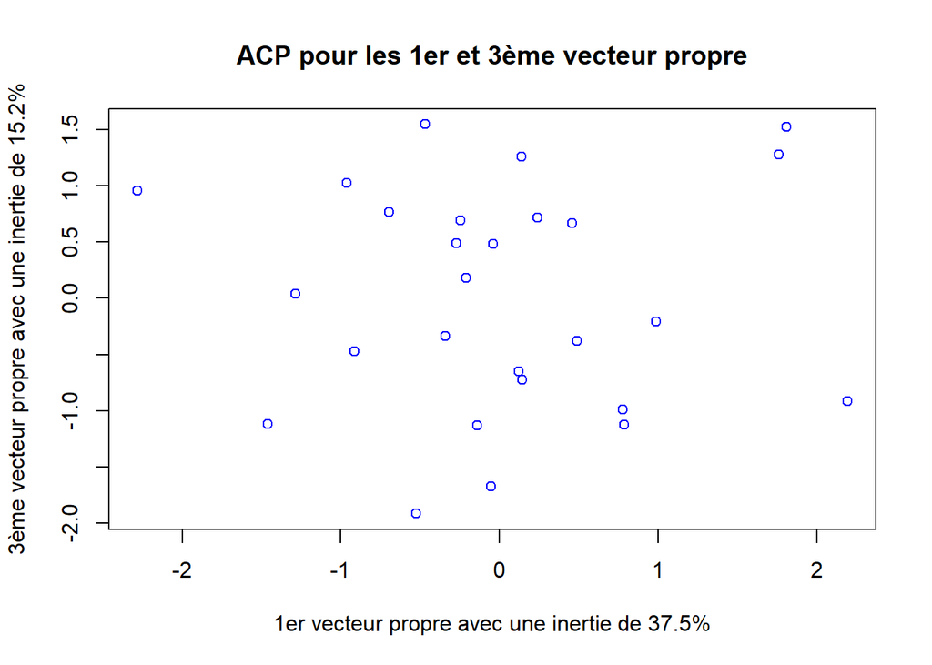

##### GGplot obtenu pour le plan factoriel des 2 plus grandes valeurs propres

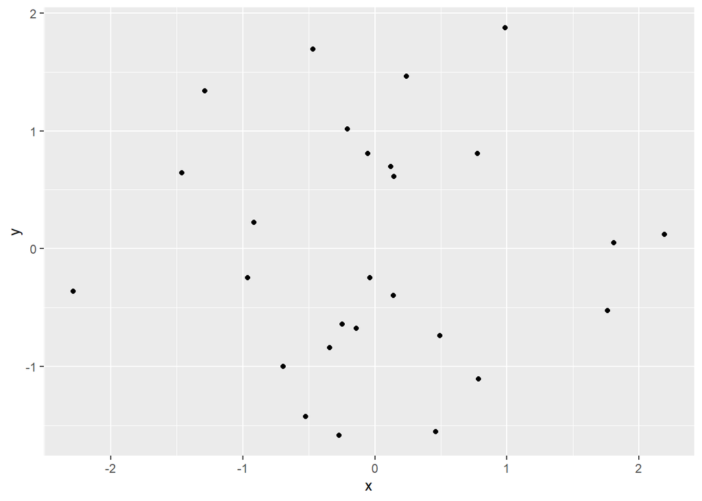

##### GGplot obtenu pour le plan factoriel de la 1ère et de la 3ème plus grande valeur propre

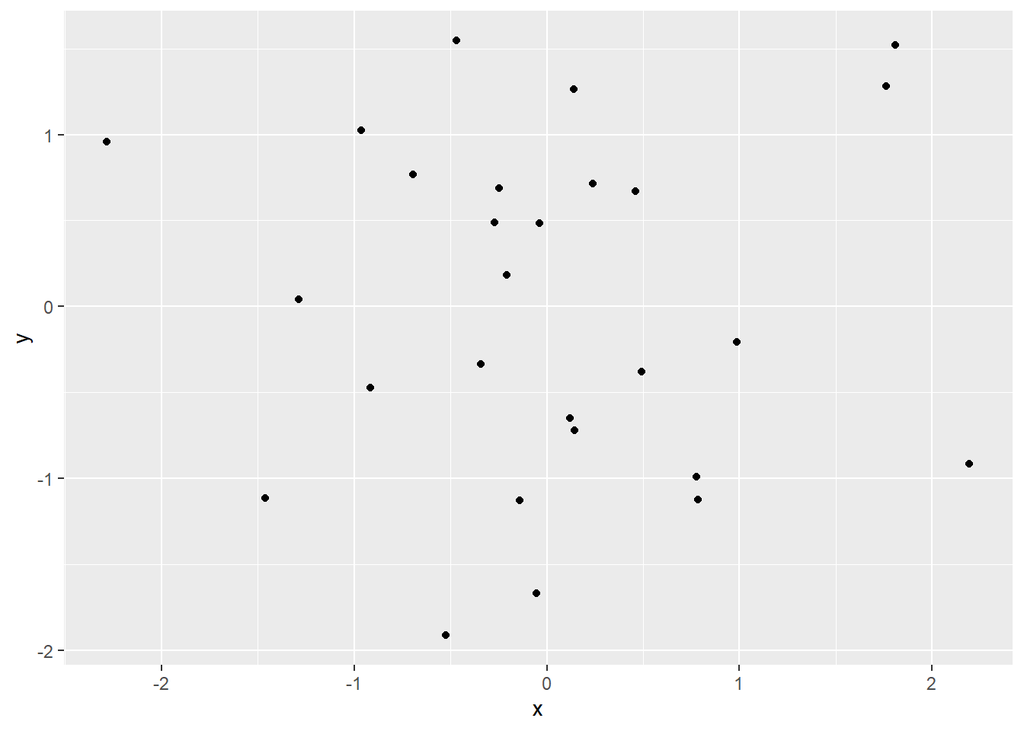

### Question 8

Déjà, on remarque que les abscisses entre les 2 graphiques n’ont pas changé puisqu’on a toujours projeté sur la 1er vecteur propre. cependant, les ordonnées des points ont elle été modifiés pusiqu’on a projeté sur la 3ème valeur propre

##### Graphique obtenue à partir de la fonction PCA déjà implémentée

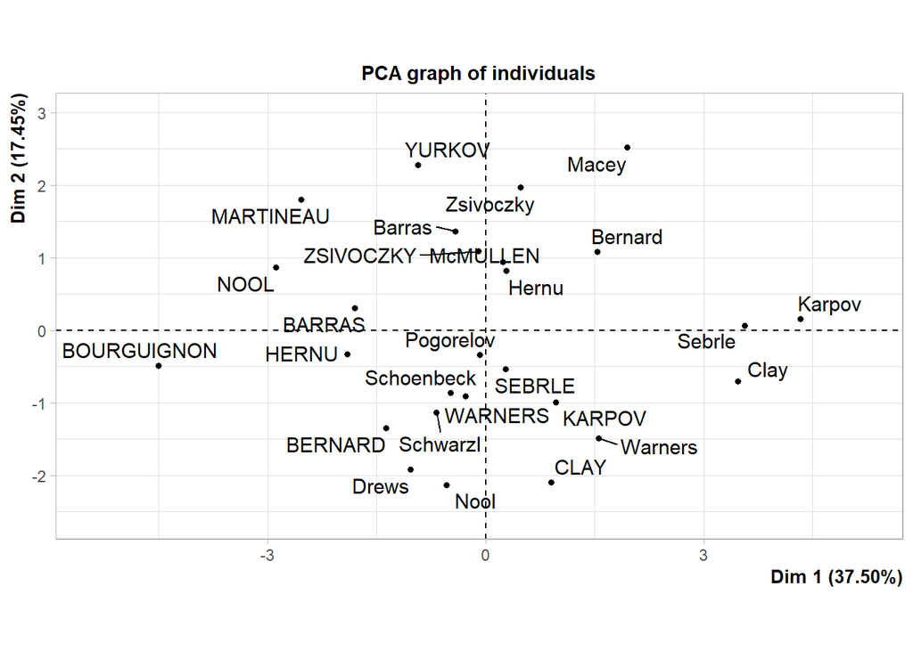

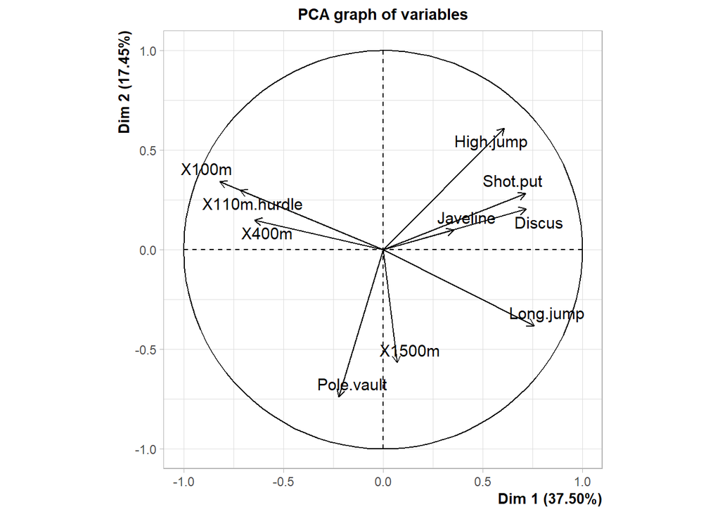

```
## **Results for the Principal Component Analysis (PCA)**
## The analysis was performed on 27 individuals, described by 10 variables
## *The results are available in the following objects:
##
##    name               description
## 1  "$eig"             "eigenvalues"
## 2  "$var"             "results for the variables"
## 3  "$var$coord"       "coord. for the variables"
## 4  "$var$cor"         "correlations variables - dimensions"
## 5  "$var$cos2"        "cos2 for the variables"
## 6  "$var$contrib"     "contributions of the variables"
## 7  "$ind"             "results for the individuals"
## 8  "$ind$coord"       "coord. for the individuals"
## 9  "$ind$cos2"        "cos2 for the individuals"
## 10 "$ind$contrib"     "contributions of the individuals"
## 11 "$call"            "summary statistics"
## 12 "$call$centre"     "mean of the variables"
## 13 "$call$ecart.type" "standard error of the variables"
## 14 "$call$row.w"      "weights for the individuals"
## 15 "$call$col.w"      "weights for the variables"
```

Par ailleurs , on peut critiquer cette ACP puisque l’inertie combinée des 2 valeurs propres n’est seulement que de 55% donc on perd près de 45% de l’information ce qui ne peut être négligé. On peut également critiquer l’ACP en dsiant qu’elle ne peut pas nous dire dans quels disciplines les individus appartenant à un cluster ont les résultats similaires

# Conclusion

Pour conclure, on peut donc dire que dans ce TP, on a appris à effectuer une ACP afin de rendre un problème qui comportait un gros volume de données plus lisible en essayant de garder les informations essentielles qui étaient présentes dans le dataset initial en les projetant dans un plan factoriel. l’ACP nous permet aussi de faire une première analyse des résultats pour comprendre les liens qui peuvent exister entre les individus via leurs performances sportives ainsi que les liaisions qui peuvent exister entre les variables.